# Contaminación Ambiental y Sus Efectos en la Salud de los Mexicanos

Authors

Mateo Yáñez-Tanaka

Fernando Ramos-Valdez

Fernando Pavía-González

Jorge Sánchez-Ponce

## Abstract

Palabras clave: calidad del aire, biomarcadores, redes bayesianas gaussianas, ENSANUT, SEMARNAT, BIC, AIC.

## Introducción

La contaminación atmosférica constituye uno de los principales riesgos ambientales para la salud, con efectos que trascienden el aparato respiratorio e inciden en procesos inflamatorios sistémicos y eventos cardiovasculares. En el contexto mexicano, la heterogeneidad regional de las emisiones —impulsada por fuentes móviles, industriales y de área— convive con variabilidad sociodemográfica y de acceso a servicios de salud, lo que complejiza la identificación de relaciones entre exposición y daño biológico. Comprender estos vínculos requiere herramientas que integren múltiples contaminantes y biomarcadores bajo supuestos transparentes de dependencia condicional y permitan responder preguntas clínicas y de política pública de forma probabilística.

Este trabajo aborda dicha necesidad mediante la integración de dos fuentes nacionales: (i) la ENSANUT, que aporta mediciones individuales de biomarcadores relacionados con inflamación y estado hematológico (proteína C reactiva, ferritina, homocisteína, transferrina, hemoglobina y albúmina), y (ii) los registros de SEMARNAT sobre emisiones y concentraciones de contaminantes criterio (NOx, CO, SO₂, PM₁₀ y PM₂.₅), priorizando fuentes de área por su mayor cobertura municipal y menor proporción de valores faltantes. La unificación, limpieza y armonización de ambas bases se realizaron en Python, garantizando consistencia semántica y numérica entre entidades y municipios.

Metodológicamente, se emplearon Redes Bayesianas Gaussianas (GBN) para modelar la estructura de dependencias entre contaminantes y biomarcadores. Las GBN representan una aproximación idónea cuando se asume normalidad multivariada y se desea descomponer la distribución conjunta en relaciones locales entre nodos, capturadas en un grafo dirigido acíclico (DAG). A partir de revisión de literatura y entrevistas con especialistas clínicos (otorrinolaringología y cardiología), se propusieron tres estructuras alternativas que codifican hipótesis sobre cómo los contaminantes impactan marcadores de inflamación, oxigenación y metabolismo del hierro. Posteriormente, las estructuras se ajustaron y compararon con criterios de información BIC y AIC, y se evaluaron consultas probabilísticas (cpquery) relevantes para la práctica clínica (p. ej., probabilidades de permanecer en rangos normales o de presentar signos de inflamación bajo distintos escenarios de exposición).

Los resultados muestran que: (1) los modelos lineales simples entre pares (contaminante–biomarcador) ofrecen un bajo ajuste, plausiblemente por no linealidades y presencia de valores atípicos; (2) la tercera DAG obtiene la mejor puntuación (margen estrecho) frente a alternativas, y (3) incorporar el sexo como variable adicional no mejora los criterios de información en la versión mixta (cg), sugiriendo que se requieren muestras mayores o especificaciones más flexibles (p. ej., modelos no paramétricos o términos de interacción). En conjunto, el estudio ilustra la utilidad de las GBN para integrar evidencia clínica y datos poblacionales, ofreciendo un marco de inferencia transparente que puede informar vigilancia epidemiológica, priorización de intervenciones y futuras líneas de investigación con modelos más flexibles y estratificación fina por grupos etarios o condiciones de vulnerabilidad.

## Metodología

Esta investigación se centró en encontrar las probabilidades de ciertos eventos que podrían ayudar a comprender mejor los efectos de la calidad del aire en la salud de la población. Para ello se utilizaron las redes bayesianas gaussianas (GBNs por sus siglas en inglés). Estas estructuras son grafos dirigidos acíclicos (DAGs por sus siglas en inglés) en los cuales todos los nodos representan variables aleatorias continuas con distribución normal y los arcos, junto con su dirección, representan dependencias condicionales. Las GBNs permiten trabajar con distribuciones condicionales locales en vez de la distribución conjunta (global)
$$X \sim N_p(\mu,\Sigma)$$
la cual es más difícil de estimar. Las GBNs también nos dan el beneficio de poder realizar queries, una forma de inferencia para encontrar probabilidades del estilo
$$\mathbb{P}(Evento|Evidencia)$$
a través de aproximaciones (con algoritmos como logic sampling o muestreo de Monte Carlo) o de manera exacta (con algoritmos como variable elimination y junction tree)

Para la creación de los modelos computacionales se usaron los lenguajes R y Python. Python se usó para la limpieza y unificación de los datos, mientras que R se usó para la inferencia estadística. Los módulos necesarios para replicar esta investigación son:

Para python:

- `pandas` para el procesamiento de los datos
- `numpy` para el manejo de arrays

Para R:

- `bnlearn` para el entrenamiento de las redes bayesianas
- `rgraphviz` para graficar las dags
- `tidyverse` para el manejo de datos
- `ggplot` para graficar funciones lineales
- `mgcv` para los modelos no paramétricos
- `gratia` para los modelos no paramétricos

Adicionalmente los datos usados para esta investigación provienen del Instituto Nacional de Estadística y Geografía (INEGI), con su Encuesta Nacional de Salud y Nutrición (ENSANUT), y la Secretaría del Medio Ambiente y Recursos Naturales (SEMARNAT), con sus sistemas de monitoreo de la calidad del aire.

## Aplicación

Para comenzar la investigación se tomaron los archivos de la ENSANUT realizada por el INEGI y se unieron con el archivo de calidad del aire de la SEMARNAT. Se entrevistaron a varios médicos y se consultaron diversos estudios para determinar qué variables podrían resultar afectadas por cambios en la calidad del aire, y se encontró que el mayor efecto de la calidad del aire en la salud de las personas se puede notar en los sistemas respiratorio y cardiovascular. (World Health Organization 2021) Aunado a esto también se denota que los efectos de estas partículas y gases nocivos fueron más notorios en las poblaciones de hombres entre las edades de 75 a 79 y más de 80, y más fuertes a través de líneas de desarrollo socioeconómico (Mao et al. 2024). Los médicos también informan que las aflicciones más comúnmente ligadas a declive en la calidad del aire son cardiopatía isquémica, enfermedad pulmonar obstructiva crónica (EPOC), asma, derrames cerebrales e incluso cáncer (World Health Organization 2021). Tomando esto en cuenta de la base de datos de pruebas médicas, se decidió conservar únicamente las variables que la literatura sugiere tienen una correlación con estas enfermedades, que en términos de esta base de datos se trató de la proteína C reactiva, ferritina, homocisteína, transferrina, concentración de hemoglobina y albúmina, que son marcadores de inflamación. Sumado a esto se decidió conservar únicamente las fuentes de área para los valores de los contaminantes en el aire, debido a que estas no tienen valores nulos y casi todos los municipios tienen este tipo de medición. Finalmente en cuanto a valores demográficos se conservaron únicamente el sexo en vista de que la literatura sugiere que son factores relevantes.

### Construyendo Las DAGS

Primero se intentó tratar este problema únicamente en términos de sus variables continuas, estas son los valores de los marcadores de inflamación en la sangre, junto con los valores de los contaminantes, después se construyó la siguiente estructura para intentar describir sus relaciones.

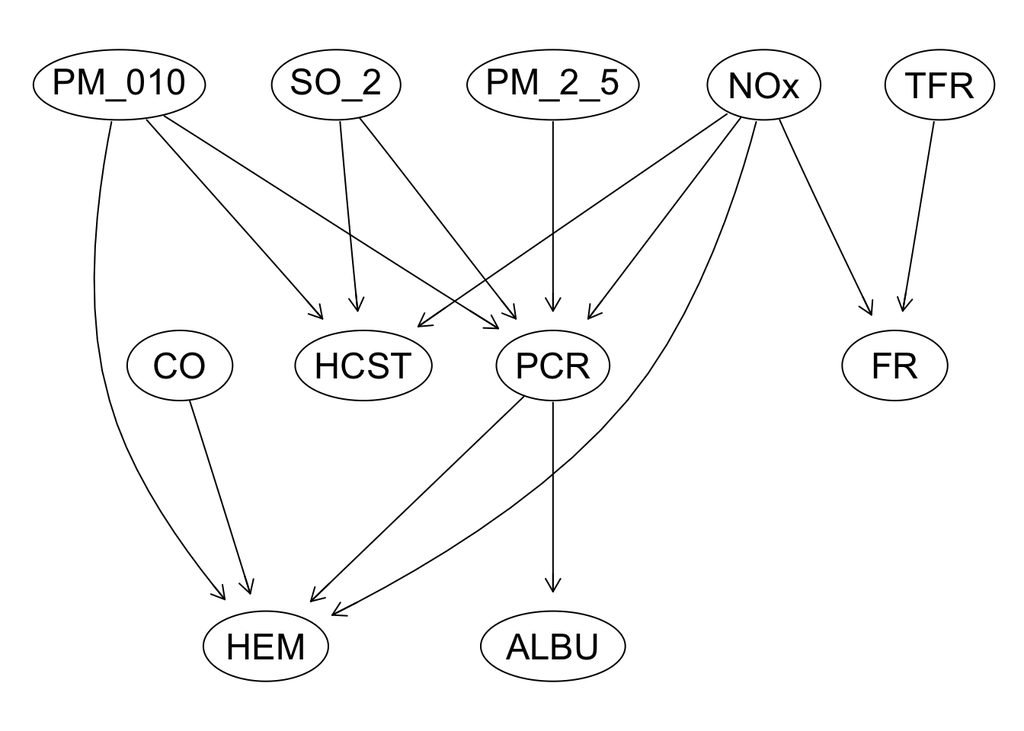

Esta estructura fue propuesta basándose en la investigación y en una entrevista con la otorrinolaringólogo Rocío Yáñez Zambrano.

En esta se propone que todos los contaminantes son independientes entre ellos junto con la transferrina (TFR). La transferrina en conjunto con los niveles de óxidos de nitrógeno ($NO_x$) en el ambiente informan la cantidad de ferritina (FR) en la sangre. Las partículas con diámetro menor o igual a 10 micrómetros ($PM_{10}$) y 2.5 micrómetros ($PM_{2.5}$) junto con la cantidad de $NO_x$ y dióxido de azufre ($SO_2$) denotan el valor de proteína C reactiva (PCR) en la sangre que representa la concentración de hemoglobina (HEM), en conjunto con el monóxido de carbono ($CO$), y valores de albúmina (ALBU) en la sangre. Finalmente, las $PM_{10}$ junto con las cantidades de $NO_x$ y $SO_2$ condicionan los valores de homocisteína (HCST) en la sangre.

La estructura de la segunda DAG propuesta fue basada en una investigación de la mano del cardiologo intervencionista Diego Guitierrez González, quien con su ayuda se encontraron relaciones entre los contaminates y los diferentes marcadores de inflamación. Es importante recalcar que también se consideró que los contaminates son independientes, aunque no son producidos por alguno de los marcadores en la sangre, o de manera general en el cuerpo, estos sí son usados o ingeridos por el cuerpo, por lo cual afectan a los marcadores de la inflamación.

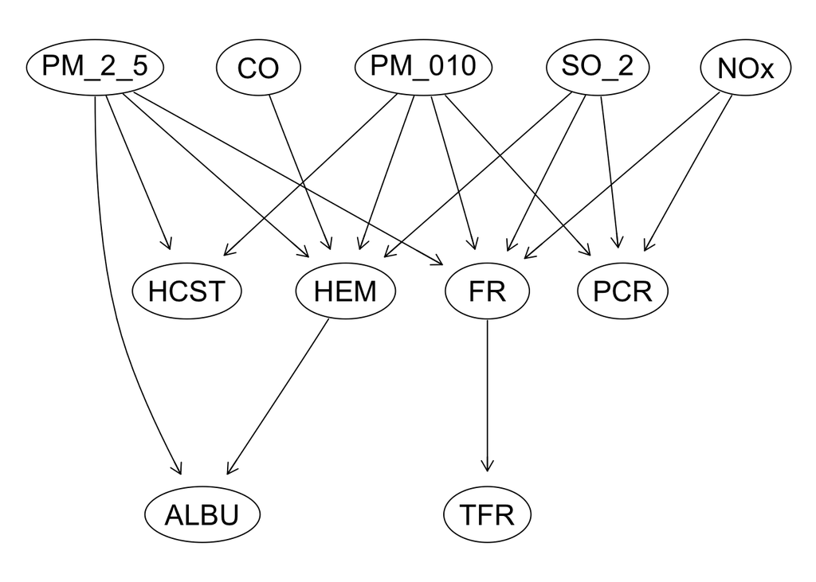

La estructura de la tercera DAG fue creada en colaboración con la doctora María José Pavía.

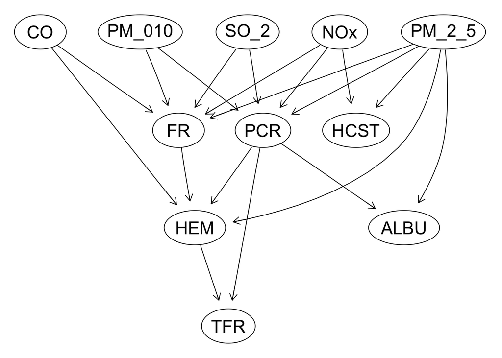

### Ajustando los modelos lineales

Después se ajustaron modelos lineales para cada una de las estructuras creadas y se observaron los resultados.

#### DAG 1

Para la primera DAG se usó el supuesto que los indicadores de mayor relevancia son la hemoglobina (HEM) y proteína C reactiva (PCR). Esto es debido a su relevancia como marcadores de inflamación y para el transporte de oxígeno a través del cuerpo. El modelo linear que se revisó es el que las compara con las $PM_{10}$ y $PM_{2.5}$ respectivamente ya que son los contaminantes con mayores efectos en el cuerpo.

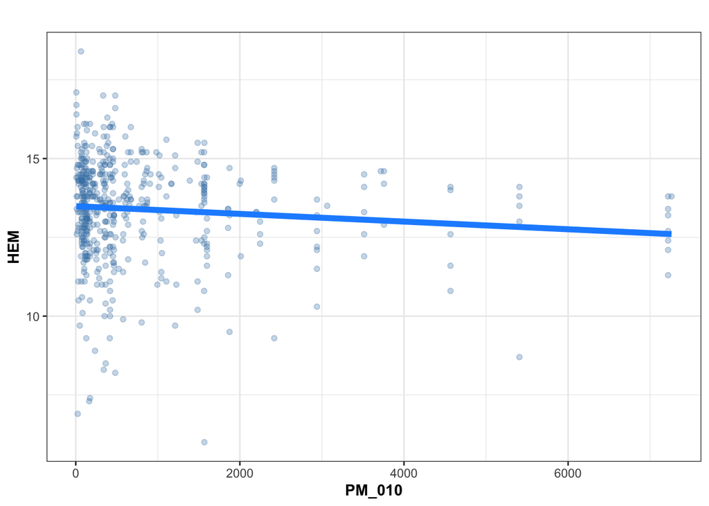

Se puede notar que el ajuste lineal deja mucho que desear y que un mejor ajuste podría ser dado por algún modelo no paramétrico.

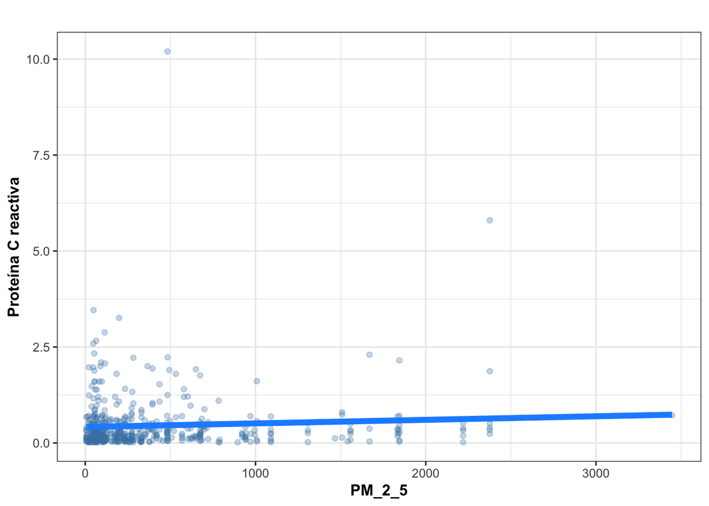

De la misma forma que en el caso anterior el ajuste líneal no parece ser el correcto, por lo cuál para un mejor ajuste se podrían utilizar modelos no paramétricos

#### DAG 2

Para la segunda estructura se exploraron los valoores de ferritina (FR) y albúmina (ALBU). Se analizaron sus modelos lineales con repecto a $NO_2$ y $PM_{2.5}$ respectivamente debido a sus fuertes relaciones teóricas con estos biomarcadores.

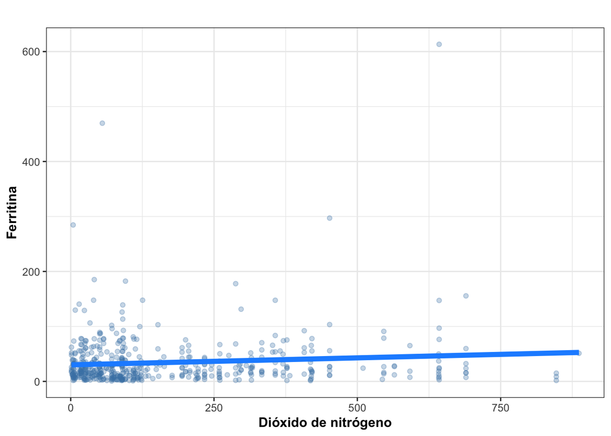

De la misma forma que con el modelo anterior el modelo lineal parece no dar el mejor ajuste puesto que hay muchos valores que caen separados de la línea y hay demasiados valores concetrados cerca del orígen. Para resolver esto podría utilizarse un modelo no paramétrico

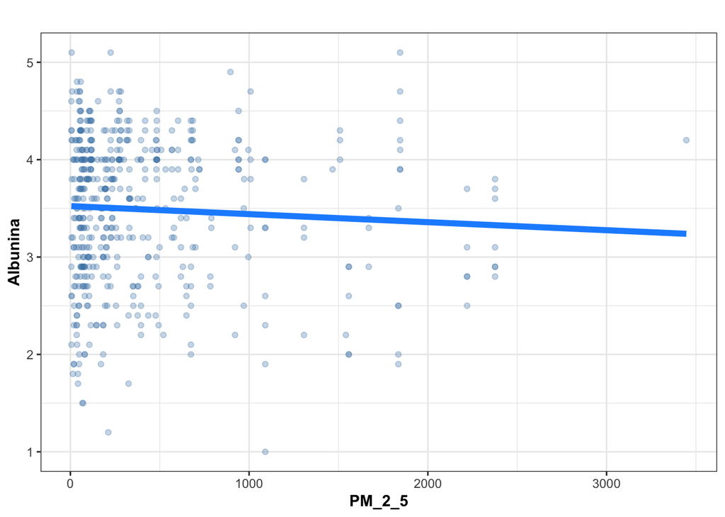

Este modelo de la misma forma que los anteriores no presentó un buen ajuste. De la misma forma que con los anteriores se podría considerar un modelo no paramétrico para un mejor ajuste.

#### DAG 3

Para el tercer modelo solo se revisó un indicador, la transferrina. Este se revisó en términos de otro biomarcador, la proteína C reactiva, esto para tener una mejor idea de cóommo es su relación al hablar de inflamación.

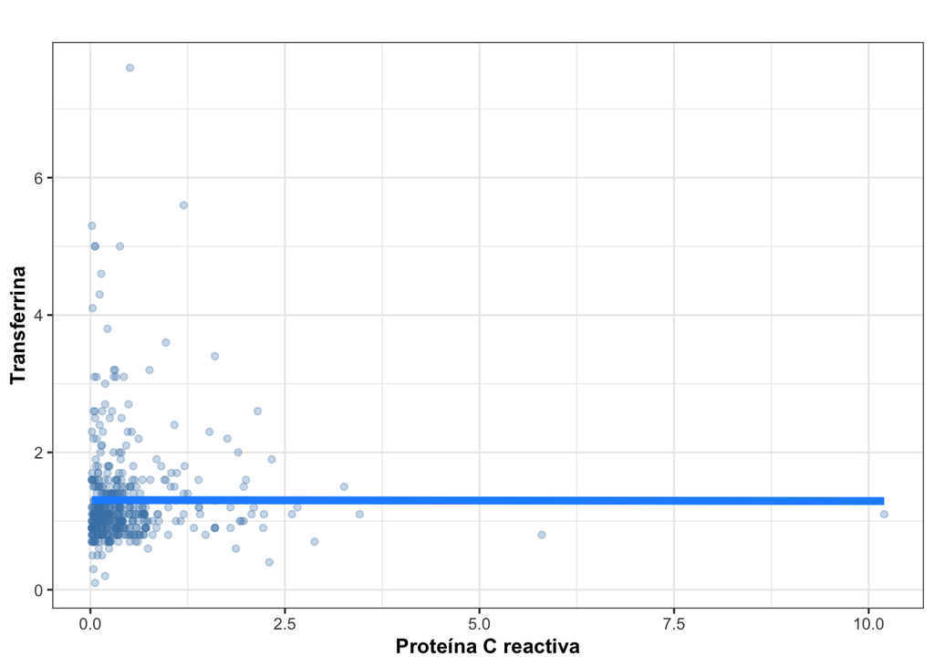

De la misma forma que coon los otros modelos el ajuste líneal no parece apropiado para estas variables debido a la alta concentración de puntos cerca del orígen.

Después de ralizar todos estos análisis se decidio que una GBN linear (LGBN) no tiene sentido para los datos; como podemos observar, en dichas comparaciones el modelo lineal no tuvo un uen ajuste, no explica muy bien los datos y no explica la mayoría de la variabbilidad. Esto pede ser causado debido a que muchas de estas variables cuentan con outliers, que sesgan el modelo. Para coonseguir un mejor ajuste se podría considerar un modelo no paramétrico.

### Comparando las DAGS

Con las DAGs ya creadas se encontró la necesidad de comparar los modelos para ver cuál representa mejor las relaciones que existen en estos datos y constestar las preguntas de investigación. Para esto se ultilizaron las pruebas de Bayesian Information Criterion (BIC) y Akaike Information Criterion (AIC).

| DAG1 | DAG2 | DAG3 |
| --- | --- | --- |
| -25257.23 | -25265.34 | -25177.85 |

Después de calcular estos puntajes usando la prueba de BIC se denotó que las 3 DAGs puntuaron de forma bastante similar con la última siendo ligeramente mejor que las otras 2.

| DAG1 | DAG2 | DAG3 |
| --- | --- | --- |
| -25181.23 | -25185.11 | -25091.28 |

De la misma forma usando el AIC se notó que el mejor puntaje era aquel de la tercera DAG pero solo de manera marginal

Tomando esta información en cuenta se decidió que la estructura a utilizar para las preguntas de investigación sería alguna versión de la tercera DAG.

### Mejor GBN incluyendo el sexo

Tras comparar las DAGs se consideró construír un cuarto modelo en el que se incluye el sexo.

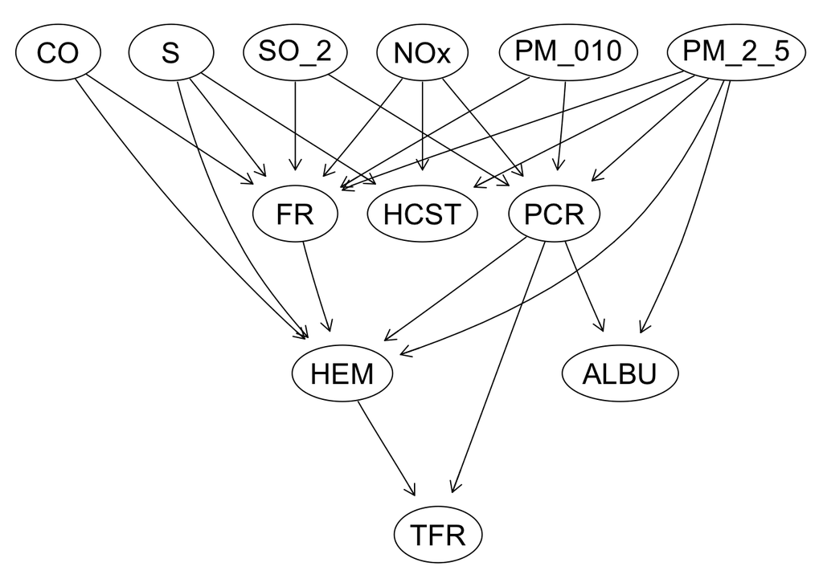

Esta estructura cumple con las mismas relaciones que la tercera, añadiendo que la concentración de hemogloina (HEM) la cantidad de ferritina (FR) y los valores de homocisteína (HCST) se ven afectados por el seco de la persona. Después se otuvieron los puntajes de esta DAG en las mismas prueas que las anteriores.

| BIC | AIC |
| --- | --- |
| -25233.85 | -25109.28 |

El desempeño de esta DAG fue peor que el desempeño de la versióon que obvia el sexo. Es debido a esto que la DAG que se usará para las preguntas de investigación (*queries*) será la propuesta por la doctora María José Pavía.

### Queries

Finalmente después de incluir el sexo se procedió a responder las preguntas de investigación propuestas por los médicos consultados, estas fueron las siguientes:

1. Propuesta por el cardiólogo Diego Gutierrez González: ¿Cúal es la probablidad de que una persona tenga un nivel irregular de ferritina dado que está en una localidad en el que se liberaron al menos 250 toneladas de $NO_x$ al año?

```
[1] 0.7161493
```

- El resultado de este query sugiere que se trata de una ocurrencia relativamente común con 71% de probabilidad de ocurrir.
2. Propuesta por la otrrinolaringólogo Rocío Yáñez Zambrano: ¿Cuál es la probabilidad de que la concentración de hemoglobina o albúmina estén abajo de los rangos normales, o la proteína C reactiva esté arriba de los valores normales dado que la persona se encuentre en un área con emisiones de $PM_{10}$, $PM_{2.5}$ y $SO_2$ elevadas?

```
[1] 0.558389
```

Mao, Qingsong, Xiaoyi Zhu, Xinyi Zhang, and Yuzhe Kong. 2024. “Effect of Air Pollution on the Global Burden of Cardiovascular Diseases and Forecasting Future Trends of the Related Metrics: A Systematic Analysis from the Global Burden of Disease Study 2021.” *Frontiers in Medicine* Volume 11 - 2024. https://doi.org/10.3389/fmed.2024.1472996.

World Health Organization. 2021. *WHO Global Air Quality Guidelines: Particulate Matter (PM2.5 and PM10), Ozone, Nitrogen Dioxide, Sulfur Dioxide and Carbon Monoxide*. Geneva: World Health Organization.